DS 6030 | Fall 2024 | University of Virginia

# Homework #5: Probability and Classification

Author

**Ashley Miller**

Published

October 9, 2024

# Required R packages and Directories

```r
dir_data= 'https://mdporter.github.io/teaching/data/' # data directory
library(glmnet)
library(tidyverse) # functions for data manipulation
library(skimr)
library(ranger)
library(pROC)
```

# Crime Linkage

Crime linkage attempts to determine if a set of unsolved crimes share a common offender. *Pairwise* crime linkage is the more simple task of deciding if two crimes share a common offender; it can be considered a binary classification problem. The linkage training data has 8 evidence variables that measure the similarity between a pair of crimes:

- `spatial` is the spatial distance between the crimes
- `temporal` is the fractional time (in days) between the crimes
- `tod` and `dow` are the differences in time of day and day of week between the crimes
- `LOC`, `POA,` and `MOA` are binary with a 1 corresponding to a match (type of property, point of entry, method of entry)
- `TIMERANGE` is the time between the earliest and latest possible times the crime could have occurred (because the victim was away from the house during the crime).
- The response variable indicates if the crimes are linked ($y=1$) or unlinked ($y=0$).

These problems use the [linkage-train](https://mdporter.github.io/teaching/data//linkage_train.csv) and [linkage-test](https://mdporter.github.io/teaching/data//linkage_test.csv) datasets (click on links for data).

## Load Crime Linkage Data

**Solution**

```r
data_train = read.csv("linkage_train.csv")
data_test = read.csv("linkage_test.csv")

#data_train = mutate(data_train, temporal = temporal/sd(temporal))
#data_test = mutate(data_test, temporal = temporal/sd(temporal))

skim(data_train)
```

Data summary

| Name | data_train |
| --- | --- |
| Number of rows | 30000 |
| Number of columns | 9 |
| _______________________ |  |
| Column type frequency: |  |
| numeric | 9 |
| ________________________ |  |
| Group variables | None |

**Variable type: numeric**

| skim_variable | n_missing | complete_rate | mean | sd | p0 | p25 | p50 | p75 | p100 | hist |
| --- | --- | --- | --- | --- | --- | --- | --- | --- | --- | --- |
| spatial | 0 | 1 | 16.31 | 9.36 | 0 | 8.63 | 16.28 | 22.72 | 56.7 | ▆▇▅▁▁ |
| temporal | 0 | 1 | 171.60 | 106.85 | 0 | 77.37 | 166.75 | 263.84 | 365.0 | ▇▇▆▆▆ |
| tod | 0 | 1 | 5.97 | 2.87 | 0 | 3.87 | 6.00 | 8.05 | 12.0 | ▃▅▇▅▃ |
| dow | 0 | 1 | 1.76 | 0.96 | 0 | 0.95 | 1.76 | 2.57 | 3.5 | ▆▆▇▆▆ |
| LOC | 0 | 1 | 0.15 | 0.36 | 0 | 0.00 | 0.00 | 0.00 | 1.0 | ▇▁▁▁▂ |
| POA | 0 | 1 | 0.36 | 0.48 | 0 | 0.00 | 0.00 | 1.00 | 1.0 | ▇▁▁▁▅ |
| MOA | 0 | 1 | 0.17 | 0.38 | 0 | 0.00 | 0.00 | 0.00 | 1.0 | ▇▁▁▁▂ |
| TIMERANGE | 0 | 1 | 32.40 | 178.96 | 0 | 0.08 | 3.36 | 12.00 | 8871.0 | ▇▁▁▁▁ |
| y | 0 | 1 | 0.02 | 0.13 | 0 | 0.00 | 0.00 | 0.00 | 1.0 | ▇▁▁▁▁ |

```r
skim(data_test)
```

Data summary

| Name | data_test |
| --- | --- |
| Number of rows | 32455 |
| Number of columns | 8 |
| _______________________ |  |
| Column type frequency: |  |
| numeric | 8 |
| ________________________ |  |
| Group variables | None |

**Variable type: numeric**

| skim_variable | n_missing | complete_rate | mean | sd | p0 | p25 | p50 | p75 | p100 | hist |
| --- | --- | --- | --- | --- | --- | --- | --- | --- | --- | --- |
| spatial | 0 | 1 | 16.92 | 10.02 | 0 | 8.66 | 16.63 | 23.93 | 58.4 | ▇▇▅▁▁ |
| temporal | 0 | 1 | 115.90 | 83.88 | 0 | 45.54 | 101.19 | 173.51 | 361.9 | ▇▆▅▂▁ |
| tod | 0 | 1 | 5.96 | 2.82 | 0 | 3.87 | 5.99 | 8.00 | 12.0 | ▃▅▇▅▂ |
| dow | 0 | 1 | 1.75 | 0.96 | 0 | 0.95 | 1.75 | 2.56 | 3.5 | ▆▇▇▇▆ |
| LOC | 0 | 1 | 0.13 | 0.34 | 0 | 0.00 | 0.00 | 0.00 | 1.0 | ▇▁▁▁▁ |
| POA | 0 | 1 | 0.31 | 0.46 | 0 | 0.00 | 0.00 | 1.00 | 1.0 | ▇▁▁▁▃ |
| MOA | 0 | 1 | 0.16 | 0.37 | 0 | 0.00 | 0.00 | 0.00 | 1.0 | ▇▁▁▁▂ |
| TIMERANGE | 0 | 1 | 26.95 | 104.97 | 0 | 0.17 | 4.50 | 13.00 | 1686.0 | ▇▁▁▁▁ |

# Problem 1: Penalized Regression for Crime Linkage

## a. Fit a penalized *linear regression* model to predict linkage.

Use an elastic net penalty (including lasso and ridge) (your choice).

- Report the value of $\alpha \in [0, 1]$ used.
- Report the value of $\lambda$ used.
- Report the estimated coefficients.

**Solution**

```r
set.seed(666)
folds = rep(1:10, length=nrow(data_train)) %>% sample()

X_tr = as.matrix(data_train[-9])
Y_tr = as.matrix(data_train$y)

el_fit = cv.glmnet(X_tr,
                   Y_tr,
                   alpha = 0.5,
                   foldid = folds)

el_trn_yhat = as.numeric(predict(el_fit, X_tr))

el_coef <- coef(el_fit)

print(el_fit$cvm[which(el_fit$lambda == el_fit$lambda.1se)])
```

```
[1] 0.0158
```

```r
print("alpha = 0.5")
```

```
[1] "alpha = 0.5"
```

```r
print(el_fit$lambda.1se)
```

```
[1] 0.0243
```

```r
print(el_coef)
```

```
9 x 1 sparse Matrix of class "dgCMatrix"
                   s1
(Intercept)  4.03e-02
spatial     -1.06e-03
temporal    -4.74e-05
tod          .
dow          .
LOC          1.18e-02
POA          .
MOA          .
TIMERANGE    .
```

## b. Fit a penalized *logistic regression* model to predict linkage.

Use an elastic net penalty (including lasso and ridge) (your choice).

- Report the value of $\alpha \in [0, 1]$ used.
- Report the value of $\lambda$ used.
- Report the estimated coefficients.

**Solution**

```r
set.seed(666)
el_logit_fit = cv.glmnet(X_tr,
                   Y_tr,
                   family = "binomial",
                   alpha = 0.5,
                   foldid = folds)

el_logit_coef <- coef(el_logit_fit)

el_logit_trn_yhat = as.numeric(predict(el_logit_fit, X_tr))

print(el_logit_fit$cvm[which(el_logit_fit$lambda == el_logit_fit$lambda.1se)])
```

```
[1] 0.0958
```

```r
print("alpha = 0.5")
```

```
[1] "alpha = 0.5"
```

```r
print(el_logit_fit$lambda.1se)
```

```
[1] 0.00237
```

```r
print(el_logit_coef)
```

```
9 x 1 sparse Matrix of class "dgCMatrix"
                   s1
(Intercept) -0.839923
spatial     -0.185762
temporal    -0.009691
tod         -0.082993
dow         -0.178370
LOC          1.305955
POA          0.308407
MOA          0.089217
TIMERANGE    0.000441
```

# Problem 2: Random Forest for Crime Linkage

Fit a random forest model to predict crime linkage.

- Report the loss function (or splitting rule) used.
- Report any non-default tuning parameters.
- Report the variable importance (indicate which importance method was used).

**Solution**

```r
data_train_factor = data_train %>%
  mutate(y = as.factor(y))
rf_mod = ranger(
        formula = y~.,
        data = data_train_factor,
        splitrule = "extratrees",
        importance = "permutation",
        probability = T,
        seed = 666
        )
rf_mod_yhat = as.numeric(predict(rf_mod, data_train_factor)$predictions[,1])

print("Split rule used: extratrees to reduce overfit")
```

```
[1] "Split rule used: extratrees to reduce overfit"
```

```r
print("Importance method: permutation")
```

```
[1] "Importance method: permutation"
```

```r
print(importance(rf_mod))
```

```
  spatial  temporal       tod       dow       LOC       POA       MOA TIMERANGE
 4.60e-03  3.40e-03  6.40e-04  4.50e-04  1.15e-03  1.76e-04  4.15e-05  2.65e-04
```

# Problem 3: ROC Curves

## a. ROC curve: training data

Produce one plot that has the ROC curves, using the *training data*, for all three models (linear, logistic, and random forest). Use color and/or linetype to distinguish between models and include a legend.  
Also report the AUC (area under the ROC curve) for each model. Again, use the *training data*.

- Note: you should be wary of being asked to evaluation predictive performance from the same data used to estimate the tuning and model parameters. The next problem will walk you through a more proper way of evaluating predictive performance with resampling.

**Solution**

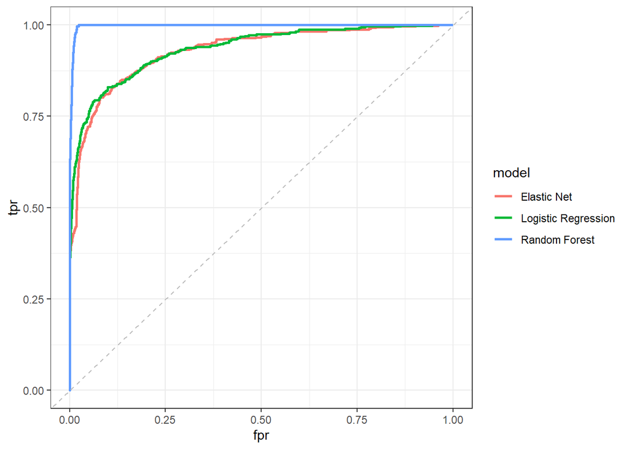

[output not shown]

## b. ROC curve: resampling estimate

Recreate the ROC curve from the penalized logistic regression (logreg) and random forest (rf) models using repeated hold-out data. The following steps will guide you:

- For logreg, use $\alpha=.75$. For rf use *mtry = 2*, *num.trees = 1000*, and fix any other tuning parameters at your choice.
- Run the following steps 25 times:
  1. Hold out 500 observations.
  2. Use the remaining observations to estimate $\lambda$ using 10-fold CV for the logreg model. Don’t tune any rf parameters.
  3. Predict the probability of linkage for the 500 hold-out observations.
  4. Store the predictions and hold-out labels.
  5. Calculate the AUC.
- Report the mean AUC and standard error for both models. Compare to the results from part a.
- Produce two plots showing the 25 ROC curves for each model.
- Note: by estimating $\lambda$ each iteration, we are incorporating the uncertainty present in estimating that tuning parameter.

**Solution**

[figure not shown]

```r
auc_el_list <- sapply(roc_list, function(x) x$el_logit$auc[1])
auc_rf_list <- sapply(roc_list, function(x) x$rf_mod$auc[1])

calculate_mean_se <- function(AUC) {
  mean_auc <- mean(AUC)
  se_auc <- sd(AUC) / sqrt(length(AUC))
  return(list(mean = mean_auc, se = se_auc))
}

mean_se_elastic_net <- calculate_mean_se(auc_el_list)

mean_se_random_forest <- calculate_mean_se(auc_rf_list)

# Print the results
cat("Elastic Net - Mean AUC:", mean_se_elastic_net$mean, "Standard Error:", mean_se_elastic_net$se, "\n")
```

```
Elastic Net - Mean AUC: 0.929 Standard Error: 0.0119
```

```r
cat("Elastic Net - Training AUC:", auc_el_logit_trn, "\n")
```

```
Elastic Net - Training AUC: 0.935
```

```r
cat("Random Forest - Mean AUC:", mean_se_random_forest$mean, "Standard Error:", mean_se_random_forest$se, "\n")
```

```
Random Forest - Mean AUC: 0.934 Standard Error: 0.0115
```

```r
cat("Random Forest - Training AUC:", auc_rf_trn, "\n")
```

```
Random Forest - Training AUC: 0.997
```

We would expect that the AUC to be lower for the nested CV/holdout set because it is attempting to capture the uncertainty of the variation, generalizing the model better.

# Problem 4: Contest

## a. Contest Part 1: Predict the estimated *probability* of linkage.

Predict the estimated *probability* of linkage for the test data (using any model).

- Submit a .csv file (ensure comma separated format) named `lastname_firstname_1.csv` that includes the column named **p** that is your estimated posterior probability. We will use automated evaluation, so the format must be exact.
- You are free to use any model (even ones we haven’t yet covered in the course).
- You are free to use any data transformation or feature engineering.
- You will receive credit for a proper submission; the top five scores will receive 2 bonus points.
- Your probabilities will be evaluated with respect to the mean negative Bernoulli log-likelihood (known as the average *log-loss* metric):
  $$L = - \frac{1}{M} \sum_{i=1}^m [y_i \log \, \hat{p}_i + (1 - y_i) \log \, (1 - \hat{p}_i)]$$
  where $M$ is the number of test observations, $\hat{p}_i$ is the prediction for the $i$th test observation, and $y_i \in \{0,1\}$ are the true test set labels.

**Solution**

```r
log_loss = function(actual, predicted) {
  ep <- 1e-15
  predicted = pmax(pmin(predicted, 1 - ep), ep)
  -mean(actual * log(predicted) + (1 - actual) * log(1 - predicted))
}

for(i in 1:3){
rf_con = ranger(y~.,
                data = data_train,
                mtry = 1,
                splitrule = "extratrees",
                min.bucket = i,
                num.trees = 1000,
                importance = "permutation",
                probability = T,
                seed = 666
                )


rf_con_probs_val = predict(rf_con, data_train)$predictions[,1]


print(log_loss(data_train$y, rf_con_probs_val))
}
```

```
[1] 0.0546
[1] 0.0561
[1] 0.0574
```

```r
rf_con = ranger(y~.,
                data = data_train,
                mtry = 1,
                splitrule = "extratrees",
                min.bucket = 14,
                num.trees = 1000,
                importance = "permutation",
                probability = T,
                seed = 666
                )
rf_con_probs = data.frame(predict(rf_con, data_test)$predictions[,1])
colnames(rf_con_probs) <- "p"
write.csv(rf_con_probs, "miller_ashley_1.csv",
          row.names = F)
```

## b. Contest Part 2: Predict the *linkage label*.

Predict the linkages for the test data (using any model).

- Submit a .csv file (ensure comma separated format) named `lastname_firstname_2.csv` that includes the column named **linkage** that takes the value of 1 for linked pairs and 0 for unlinked pairs. We will use automated evaluation, so the format must be exact.
- You are free to any model (even ones we haven’t yet covered in the course).
- You are free to use any data transformation or feature engineering.
- Your labels will be evaluated based on total cost, where cost is equal to `1*FP + 8*FN`. This implies that False Negatives (FN) are 8 times as costly as False Positives (FP).
- You will receive credit for a proper submission; the top five scores will receive 2 bonus points. Note: you only will get bonus credit for one of the two contests.

**Solution**

```r
cost = function(actual, predicted, t){
  predicted = ifelse(predicted>t, 1,0)
  actual = as.factor(actual)
  predicted = as.factor(predicted)

  FP = sum(actual == 0 & predicted == 1)
  FN = sum(actual == 1 & predicted == 0)
  TP = sum(actual == 1 & predicted == 1)
  TN = sum(actual == 0 & predicted == 0)

  return(FP+(8*FN))
}


rf_con_lab = ranger(y~.,
                data = data_train[-c(1,2)],
                mtry = 1,
                num.trees = 1000,
                importance = "permutation",
                probability = T,
                seed = 666
                )


rf_con_lab_val = predict(rf_con_lab, data_train)$predictions[,1]

#rf_con_lab_val = ifelse(rf_con_lab_val > i, 1, 0)


thresh = seq(0.01,.99, by = .01)
costs = sapply(thresh, function(t){
  cost(data_train$y, rf_con_lab_val, t)
})

min_cost = min(costs)

opt_t = thresh[costs == min_cost]

final_t = opt_t[which.min(abs(opt_t-0.5))]

rf_con = ranger(y~.,
                data = data_train[-c(1,2)],
                mtry = 1,
                splitrule = "extratrees",
                num.trees = 1000,
                importance = "permutation",
                probability = T,
                seed = 666
                )

rf_con_lab_hat = data.frame(predict(rf_con, data_test)$predictions[,1])
rf_con_lab_hat = ifelse(rf_con_lab_hat > final_t, 1, 0)
colnames(rf_con_lab_hat) <- "linkage"
write.csv(rf_con_lab_hat, "miller_ashley_2.csv",
          row.names = F)

#print(importance(rf_con))
table(rf_con_lab_hat)
```

```
rf_con_lab_hat
    0     1
31940   515
```